# Agrupación de Datos - Final Project - Obesidad

### **⚛️ A. Titulo: Proyecto 4 – Agrupación de datos sobre obesidad**

### **⚛️ B. Integrantes**

Jiliar Antonio Silgado Cardona

#### **⭕️ Introducción**

En la actualidad, la obesidad se ha convertido en un problema de salud pública significativo en varios países de América Latina, incluido México, Perú y Colombia. Evaluar los niveles de obesidad de manera precisa es fundamental tanto para los profesionales de la salud como para las instituciones que buscan implementar políticas de prevención efectivas. Este desafío se complica por la variedad de hábitos alimenticios y condiciones físicas que influyen en el estado de salud de los individuos. Mediante el uso de modelos de machine learning y análisis de datos, es posible identificar patrones en los hábitos de alimentación y las condiciones físicas que afectan los niveles de obesidad. Este enfoque permite desarrollar modelos de clasificación supervisada que predicen el nivel de obesidad a partir de 17 atributos relevantes, optimizando así el proceso de evaluación y apoyando decisiones informadas. Los registros, que incluyen clasificaciones como Peso Insuficiente, Peso Normal, Sobrepeso Nivel I, Sobrepeso Nivel II, Obesidad Tipo I, Obesidad Tipo II y Obesidad Tipo III, se alimentan en un 77% de datos generados sintéticamente y un 23% de datos recopilados directamente de los usuarios a través de una plataforma web. Este enfoque no solo mejora la precisión en la estimación de los niveles de obesidad, sino que también proporciona una base sólida para la intervención y la investigación en salud pública.

#### **⭕️ Núcleo Problémico**

Ante el creciente problema de obesidad en México, Perú y Colombia, las autoridades sanitarias se ven en la necesidad de implementar estrategias efectivas para clasificar y abordar los diferentes niveles de obesidad en la población. Sin embargo, la ausencia de un sistema de evaluación basado en datos precisos y objetivos dificulta la identificación de los individuos en riesgo y la formulación de intervenciones adecuadas. La dependencia de criterios subjetivos en la clasificación de niveles como Peso Insuficiente, Peso Normal y distintos grados de Obesidad puede resultar en una asignación ineficaz de recursos y en la falta de programas de prevención adaptados a las necesidades específicas de la población. Es fundamental analizar cómo las variables relacionadas con los hábitos alimenticios y el estado físico se correlacionan con la obesidad para poder desarrollar modelos de clasificación precisos. Sin un enfoque basado en datos, las decisiones tomadas pueden carecer de fundamento y no abordar eficazmente el problema de salud pública, afectando tanto la calidad de vida de los individuos como la eficacia de las políticas de salud implementadas.

#### **⭕️ Pregunta Problemica**

¿Puede un modelo de aprendizaje automático basado en los hábitos alimenticios y las condiciones físicas mejorar la clasificación de los niveles de obesidad, proporcionando una evaluación más objetiva y precisa que beneficie la salud pública y optimice la asignación de recursos en programas de prevención?

#### **⭕️ Metodología**

El análisis de agrupamientos comienza con una reducción de dimensionalidad mediante ACP, seguida de un agrupamiento k-means usando el método del codo para definir el número óptimo de clústeres. Se evalúa la relación entre los clústeres y los niveles de obesidad en el dataset. En la fase de entrenamiento supervisado, se selecciona el modelo con mejor desempeño y se reentrena añadiendo los clústeres como características. Posteriormente, se realiza optimización de hiperparámetros con técnicas como grid search. Finalmente, se generan visualizaciones de los resultados y se realiza un análisis de interpretabilidad con SHAP o LIME. El proyecto concluye con un informe final que documenta los hallazgos.

### **🔍 1. Exploración de los datos**

#### **⭕️ Introducción a la Fase de Exploración de Datos**

En esta fase inicial del análisis de datos, se realiza una exploración preliminar del conjunto de datos para comprender su estructura y características básicas. Esta etapa es crucial para identificar los aspectos fundamentales del dataset y preparar el terreno para un análisis más profundo.

Durante la exploración, se utilizan diversas instrucciones para obtener una visión general del conjunto de datos:

### **⭕️ Entendimiento de los datos**

La base de datos a utilizar se denomina ObesityDataSet_raw_and_data_sinthetic.csv. Esta contiene información sobre los niveles de obesidad en individuos de México, Perú y Colombia, y se centra en sus hábitos alimenticios y condiciones físicas. El conjunto de datos incluye 17 atributos que abarcan variables cuantitativas y categóricas, como el índice de masa corporal (IMC), nivel de actividad física, consumo de alimentos específicos y variables sociodemográficas. Además, se cuenta con una variable de clase denominada NObesity, que clasifica a los individuos en categorías como Peso Insuficiente, Peso Normal, Sobrepeso y diferentes niveles de Obesidad (Tipo I, Tipo II y Tipo III). Esta base es esencial para analizar y modelar la relación entre los hábitos alimenticios, el estado físico y los niveles de obesidad, facilitando el desarrollo de modelos de aprendizaje automático que pueden contribuir a la salud pública y la prevención de enfermedades relacionadas con la obesidad.

[output not shown]

```python
# Cargar librerías necesarias para análisis y visualización de datos
import seaborn as sns  # Para visualización de datos en gráficos
import pandas as pd    # Para manipulación de datos utilizando estructuras tipo DataFrame
import numpy as np     # Para operaciones numéricas y manejo de arreglos y matrices
import matplotlib.pyplot as plt  # Para crear gráficos en 2D y visualizar datos
import json            # Para manipular diccionarios y trabajar con datos en formato JSON
import shap

# Importar las bibliotecas necesarias para el modelo supervisado
from sklearn.model_selection import train_test_split, GridSearchCV, RandomizedSearchCV
from sklearn.ensemble import RandomForestClassifier
from sklearn.linear_model import LogisticRegression
from sklearn.svm import SVC
from xgboost import XGBClassifier

# Importar algoritmos de clustering para análisis de agrupamiento
from sklearn.cluster import KMeans, AgglomerativeClustering, DBSCAN  # Algoritmos de clustering: K-Means, Jerárquico y DBSCAN
from sklearn.preprocessing import StandardScaler, LabelEncoder, label_binarize  # Para normalizar las características de los datos antes de aplicar clustering

# Importar métricas para evaluar la calidad de los clusters
from sklearn.metrics import pairwise_distances_argmin_min, classification_report, confusion_matrix
from sklearn.metrics import ConfusionMatrixDisplay, roc_curve, auc, RocCurveDisplay, f1_score, recall_score, silhouette_score
from sklearn.metrics import homogeneity_score, completeness_score, v_measure_score, calinski_harabasz_score, davies_bouldin_score
from sklearn.datasets import make_blobs
# Importar GaussianMixture para aplicar el modelo de mezclas gaussianas (GMM) en clustering
from sklearn.mixture import GaussianMixture  # Algoritmo GaussianMixture para modelar datos que siguen distribuciones gaussianas

# Importar t-SNE para reducción de dimensionalidad en visualización de datos de alta dimensión
from sklearn.manifold import TSNE  # Para reducir dimensionalidad y visualizar datos en 2D o 3D

# Importar PCA para reducción de dimensionalidad en datos de alta dimensión
from sklearn.decomposition import PCA  # Para transformar datos a componentes principales con menor dimensión

# Importar funciones para serializar y cargar modelos grandes o complejos
from joblib import dump, load  # Para guardar (dump) y cargar (load) modelos de machine learning y grandes volúmenes de datos

# Ignorar advertencias innecesarias para mejorar legibilidad en las salidas
import warnings
warnings.filterwarnings("ignore")  # Desactivar advertencias para evitar mensajes no esenciales en el análisis
```

```python
#Lectura de origen de datos:
df = pd.read_csv('../Datos/ObesityDataSet_raw_and_data_sinthetic.csv')
```

```python
# Información de Dataframe
print("Información general del DataFrame:\n")
df.info()

# mostrar el tamaño de la memoria utilizada por el DataFrame
print("\n Memoria utilizada por el DataFrame (bytes):\n")
print(df.memory_usage(deep=True))
```

```
Información general del DataFrame:

<class 'pandas.core.frame.DataFrame'>
RangeIndex: 2111 entries, 0 to 2110
Data columns (total 17 columns):
 #   Column                          Non-Null Count  Dtype
---  ------                          --------------  -----
 0   Gender                          2111 non-null   object
 1   Age                             2111 non-null   float64
 2   Height                          2111 non-null   float64
 3   Weight                          2111 non-null   float64
 4   family_history_with_overweight  2111 non-null   object
 5   FAVC                            2111 non-null   object
 6   FCVC                            2111 non-null   float64
 7   NCP                             2111 non-null   float64
 8   CAEC                            2111 non-null   object
 9   SMOKE                           2111 non-null   object
 10  CH2O                            2111 non-null   float64
 11  SCC                             2111 non-null   object
 12  FAF                             2111 non-null   float64
 13  TUE                             2111 non-null   float64
 14  CALC                            2111 non-null   object
 15  MTRANS                          2111 non-null   object
 16  NObeyesdad                      2111 non-null   object
dtypes: float64(8), object(9)
memory usage: 280.5+ KB

 Memoria utilizada por el DataFrame (bytes):

Index                                128
Gender                            130857
Age                                16888
Height                             16888
Weight                             16888
family_history_with_overweight    126275
FAVC                              126415
FCVC                               16888
NCP                                16888
CAEC                              139052
SMOKE                             124593
CH2O                               16888
SCC                               124645
FAF                                16888
TUE                                16888
CALC                              134920
MTRANS                            158596
NObeyesdad                        154509
dtype: int64
```

### **⭕️ Diccionario de datos**

Este diccionario de datos ofrece una descripción exhaustiva de las columnas del dataframe obtenido del archivo **`ObesityDataSet_raw_and_data_sinthetic.csv`**. Cada columna se detalla con su tipo de dato, proporcionando una breve explicación de lo que representa cada variable en relación con los hábitos alimenticios y condiciones físicas de los individuos analizados. Además, se incluye información sobre el tamaño en bytes ocupado por cada tipo de dato, lo que permite comprender mejor el espacio de almacenamiento requerido para el conjunto de datos.

El objetivo de este diccionario es facilitar la comprensión de la estructura del conjunto de datos, ayudando en el análisis y la manipulación de la información, así como en la implementación de modelos de aprendizaje automático para la clasificación de niveles de obesidad. Con una clara representación de las variables, se busca optimizar la interpretación de los resultados y las conclusiones derivadas del análisis.

[output not shown]

### **⭕️ Dimensiones del Dataframe (Filas x Columnas)**

```python
#Forma del dataframe
print(f'Forma de Dataframe Consolidado de Vinos: {df.shape}')
```

```
Forma de Dataframe Consolidado de Vinos: (2111, 17)
```

#### **⭕️ Primeras filas del DataFrame**

```python
df.head()
```

|  | Gender | Age | Height | Weight | family_history_with_overweight | FAVC | FCVC | NCP | CAEC | SMOKE | CH2O | SCC | FAF | TUE | CALC | MTRANS | NObeyesdad |
| --- | --- | --- | --- | --- | --- | --- | --- | --- | --- | --- | --- | --- | --- | --- | --- | --- | --- |
| 0 | Female | 21.0 | 1.62 | 64.0 | yes | no | 2.0 | 3.0 | Sometimes | no | 2.0 | no | 0.0 | 1.0 | no | Public_Transportation | Normal_Weight |
| 1 | Female | 21.0 | 1.52 | 56.0 | yes | no | 3.0 | 3.0 | Sometimes | yes | 3.0 | yes | 3.0 | 0.0 | Sometimes | Public_Transportation | Normal_Weight |
| 2 | Male | 23.0 | 1.80 | 77.0 | yes | no | 2.0 | 3.0 | Sometimes | no | 2.0 | no | 2.0 | 1.0 | Frequently | Public_Transportation | Normal_Weight |
| 3 | Male | 27.0 | 1.80 | 87.0 | no | no | 3.0 | 3.0 | Sometimes | no | 2.0 | no | 2.0 | 0.0 | Frequently | Walking | Overweight_Level_I |
| 4 | Male | 22.0 | 1.78 | 89.8 | no | no | 2.0 | 1.0 | Sometimes | no | 2.0 | no | 0.0 | 0.0 | Sometimes | Public_Transportation | Overweight_Level_II |

#### **⭕️ Últimas filas del DataFrame**

```python
# ultimos registros
df.tail()
```

|  | Gender | Age | Height | Weight | family_history_with_overweight | FAVC | FCVC | NCP | CAEC | SMOKE | CH2O | SCC | FAF | TUE | CALC | MTRANS | NObeyesdad |
| --- | --- | --- | --- | --- | --- | --- | --- | --- | --- | --- | --- | --- | --- | --- | --- | --- | --- |
| 2106 | Female | 20.976842 | 1.710730 | 131.408528 | yes | yes | 3.0 | 3.0 | Sometimes | no | 1.728139 | no | 1.676269 | 0.906247 | Sometimes | Public_Transportation | Obesity_Type_III |
| 2107 | Female | 21.982942 | 1.748584 | 133.742943 | yes | yes | 3.0 | 3.0 | Sometimes | no | 2.005130 | no | 1.341390 | 0.599270 | Sometimes | Public_Transportation | Obesity_Type_III |
| 2108 | Female | 22.524036 | 1.752206 | 133.689352 | yes | yes | 3.0 | 3.0 | Sometimes | no | 2.054193 | no | 1.414209 | 0.646288 | Sometimes | Public_Transportation | Obesity_Type_III |
| 2109 | Female | 24.361936 | 1.739450 | 133.346641 | yes | yes | 3.0 | 3.0 | Sometimes | no | 2.852339 | no | 1.139107 | 0.586035 | Sometimes | Public_Transportation | Obesity_Type_III |
| 2110 | Female | 23.664709 | 1.738836 | 133.472641 | yes | yes | 3.0 | 3.0 | Sometimes | no | 2.863513 | no | 1.026452 | 0.714137 | Sometimes | Public_Transportation | Obesity_Type_III |

#### **⭕️ Tamaño total del DataFrame en términos de número de filas**

```python
# total de registros
total_size = len(df)
print(f'Tamaño (Número de Filas): {total_size}')
```

```
Tamaño (Número de Filas): 2111
```

#### **⭕️ Columnas (Variables) en Dataframe**

```python
# nombres de las columnas
print("\nNombres de las columnas:")
print(df.columns)
```

```
Nombres de las columnas:
Index(['Gender', 'Age', 'Height', 'Weight', 'family_history_with_overweight',
       'FAVC', 'FCVC', 'NCP', 'CAEC', 'SMOKE', 'CH2O', 'SCC', 'FAF', 'TUE',
       'CALC', 'MTRANS', 'NObeyesdad'],
      dtype='object')
```

#### **⭕️ Número Total de Variables**

```python
# Número total de variables que contiene la base de datos.
num_columnas = df.shape[1]
print(f'Número de variables (columnas): {num_columnas}')
```

```
Número de variables (columnas): 17
```

#### **⭕️ Variables con datos faltantes, Porcentaje total de valores faltantes en la base de datos.**

```python
import json

def valores_faltantes_por_columna(df):
    # Escribir las variables que tienen datos faltantes, además, proporcionar el porcentaje total de valores faltantes en la base de datos.
    # Paso 1: Encontrar columnas con valores faltantes
    faltantes_por_columna = df.isnull().sum()

    # Paso 2: Filtrar columnas que tienen valores faltantes
    data1 = faltantes_por_columna[faltantes_por_columna > 0]
    variables_con_faltantes = data1.to_dict()

    print('\nCant. valores faltantes por columna:',
          json.dumps(variables_con_faltantes, indent=4),
          sep="\n")

    # Paso 3: Calcular el porcentaje de valores faltantes por columna
    data = (data1 / len(df)) * 100
    data = data.to_dict()
    porcentaje_faltantes_por_columna = {key: f'{value:.2f}%' for key, value in data.items()}

    # Paso 4: Calcular el porcentaje total de valores faltantes en el DataFrame
    porcentaje_total_faltantes = (df.isnull().sum().sum() / df.size) * 100
    porcentaje_total_no_faltantes = (df.notnull().sum().sum() / df.size) * 100

    # Resultados
    print('\n% valores faltantes por columna:', f'{json.dumps(porcentaje_faltantes_por_columna, indent=4)}', sep="\n")

    print(f"\nPorcentaje total de valores faltantes en la base de datos: {porcentaje_total_faltantes:.2f}%")
    print(f"Porcentaje total de valores en la base de datos: {porcentaje_total_no_faltantes:.2f}%")

valores_faltantes_por_columna(df)
```

```
Cant. valores faltantes por columna:
{}

% valores faltantes por columna:
{}

Porcentaje total de valores faltantes en la base de datos: 0.00%
Porcentaje total de valores en la base de datos: 100.00%
```

#### **⭕️ Información estadistica del DataFrame**

```python
df.describe()
```

|  | Age | Height | Weight | FCVC | NCP | CH2O | FAF | TUE |
| --- | --- | --- | --- | --- | --- | --- | --- | --- |
| count | 2111.000000 | 2111.000000 | 2111.000000 | 2111.000000 | 2111.000000 | 2111.000000 | 2111.000000 | 2111.000000 |
| mean | 24.312600 | 1.701677 | 86.586058 | 2.419043 | 2.685628 | 2.008011 | 1.010298 | 0.657866 |
| std | 6.345968 | 0.093305 | 26.191172 | 0.533927 | 0.778039 | 0.612953 | 0.850592 | 0.608927 |
| min | 14.000000 | 1.450000 | 39.000000 | 1.000000 | 1.000000 | 1.000000 | 0.000000 | 0.000000 |
| 25% | 19.947192 | 1.630000 | 65.473343 | 2.000000 | 2.658738 | 1.584812 | 0.124505 | 0.000000 |
| 50% | 22.777890 | 1.700499 | 83.000000 | 2.385502 | 3.000000 | 2.000000 | 1.000000 | 0.625350 |
| 75% | 26.000000 | 1.768464 | 107.430682 | 3.000000 | 3.000000 | 2.477420 | 1.666678 | 1.000000 |
| max | 61.000000 | 1.980000 | 173.000000 | 3.000000 | 4.000000 | 3.000000 | 3.000000 | 2.000000 |

#### **⭕️ Conteo por nivel de obesidad del individuo.**

```python
df['NObeyesdad'].value_counts()
```

```
NObeyesdad
Obesity_Type_I         351
Obesity_Type_III       324
Obesity_Type_II        297
Overweight_Level_I     290
Overweight_Level_II    290
Normal_Weight          287
Insufficient_Weight    272
Name: count, dtype: int64
```

#### **⭕️ Clasificación de variables en cualitativas y numéricas.**

```python
# Diccionario de mapeo para convertir los valores cualitativos a numéricos
obesity_mapping = {
    "Normal_Weight": 0,
    "Overweight_Level_I": 1,
    "Overweight_Level_II": 2,
    "Obesity_Type_I": 3,
    "Obesity_Type_II": 4,
    "Obesity_Type_III": 5,
    "Insufficient_Weight": 6
}

# Aplicar el mapeo en la columna 'NObeyesdad'
df["NObeyesdad"] = df["NObeyesdad"].map(obesity_mapping)
df["NObeyesdad"].value_counts()
```

```
NObeyesdad
3    351
5    324
4    297
1    290
2    290
0    287
6    272
Name: count, dtype: int64
```

```python
# Clasificar las variables numéricas y cualitativas en el DataFrame df
# Seleccionar las columnas que son de tipo numérico (int64 y float64)
variables_numericas = df.select_dtypes(include=['int64', 'float64']).columns.tolist()

# Seleccionar las columnas que son de tipo cualitativo (object, category o boolean)
variables_cualitativas = df.select_dtypes(include=['object', 'category', 'bool']).columns.tolist()

# Imprimir las variables numéricas encontradas en el DataFrame
print("\nVariables numéricas:", variables_numericas, sep="\n")

# Imprimir las variables cualitativas encontradas en el DataFrame
print("\nVariables cualitativas:", variables_cualitativas, sep="\n")

df['NObeyesdad'] = df['NObeyesdad'].astype('object')

#Eliminar variables a no utilizar
df.drop(columns=['Age', 'Height', 'Weight'], inplace=True)
variables_numericas = df.select_dtypes(include=['int64', 'float64']).columns.tolist()
```

```
Variables numéricas:
['Age', 'Height', 'Weight', 'FCVC', 'NCP', 'CH2O', 'FAF', 'TUE', 'NObeyesdad']

Variables cualitativas:
['Gender', 'family_history_with_overweight', 'FAVC', 'CAEC', 'SMOKE', 'SCC', 'CALC', 'MTRANS']
```

#### **⭕️ Consideraciones**

Se han ajustado las variables en estudio, eliminando aquellas con una relación directa con el cálculo del Índice de Masa Corporal (IMC), Altura, Peso.

La Edad tambien la removeremos del analisis porque la edad es asimetrica e indica que hay un número mayor de individuos más jóvenes, lo que podría generar grupos desbalanceados y esto puede complicar la agrupación.

Este cambio permite centrar el análisis en los hábitos de alimentación y estilo de vida que podrían influir en el nivel de obesidad, excluyendo factores físicos inherentes que, al haber mostrado una relación directa con la clasificación de obesidad, podrían sesgar los resultados al no reflejar exclusivamente los efectos de los hábitos.

```python
variables_numericas = df.select_dtypes(include=['int64', 'float64']).columns.tolist()
variables_cualitativas = df.select_dtypes(include=['object', 'category', 'bool']).columns.tolist()
print("\nVariables numéricas:", variables_numericas, sep="\n")
print("\nVariables cualitativas:", variables_cualitativas, sep="\n")
```

```
Variables numéricas:
['FCVC', 'NCP', 'CH2O', 'FAF', 'TUE']

Variables cualitativas:
['Gender', 'family_history_with_overweight', 'FAVC', 'CAEC', 'SMOKE', 'SCC', 'CALC', 'MTRANS', 'NObeyesdad']
```

### **⚛️ Exploración No Supervisada**

#### **⭕️ Reducción de Dimensionalidad**

Análisis de Componentes Principales (ACP) en el dataset para simplificar y visualizar las dimensiones más relevantes.

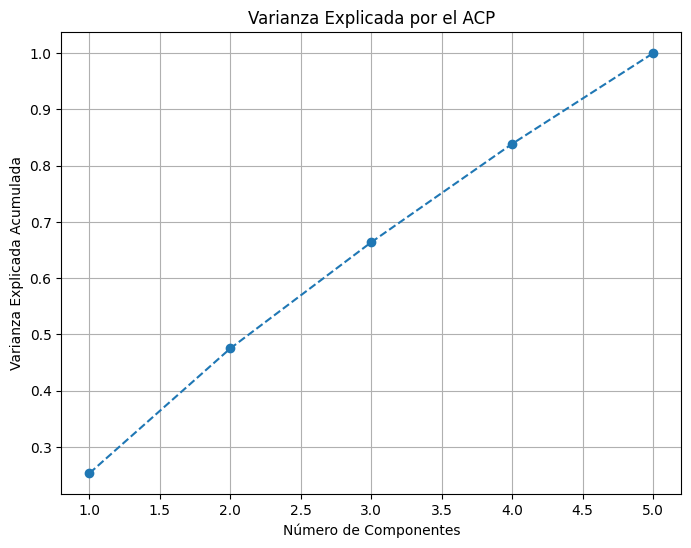

```
Componente 1: 0.2534 varianza explicada
Componente 2: 0.2219 varianza explicada
Componente 3: 0.1887 varianza explicada
Componente 4: 0.1749 varianza explicada
Componente 5: 0.1611 varianza explicada
Número de componentes seleccionados: 4
```

```python
# Seleccionar las variables numéricas y la variable objetivo (obesidad)
X = df[variables_numericas]  # Variables numéricas (entradas del modelo)
y = np.array(df['NObeyesdad'])  # Variable objetivo (nivel de obesidad)

# Estandarizar las variables para que tengan media 0 y desviación estándar 1
scaler = StandardScaler()  # Inicializamos el escalador
X_scaled = scaler.fit_transform(X)  # Aplicamos la transformación a las variables

# Fijar una semilla para asegurar la reproducibilidad de los resultados
np.random.seed(42)  # Establecemos la semilla para que el proceso sea reproducible

# Realizar el Análisis de Componentes Principales (ACP) para reducir la dimensionalidad
pca = PCA()  # Inicializamos el PCA sin definir el número de componentes
X_pca = pca.fit_transform(X_scaled)  # Aplicamos el ACP a los datos escalados

# Graficar la varianza explicada acumulada para decidir el número de componentes
plt.figure(figsize=(8, 6))  # Establecemos el tamaño de la figura
plt.plot(range(1, len(pca.explained_variance_ratio_) + 1),
         pca.explained_variance_ratio_.cumsum(), marker='o', linestyle='--')  # Graficamos la varianza acumulada
plt.xlabel('Número de Componentes')  # Etiqueta del eje X
plt.ylabel('Varianza Explicada Acumulada')  # Etiqueta del eje Y
plt.title('Varianza Explicada por el ACP')  # Título del gráfico
plt.grid()  # Agregamos una cuadrícula para mejorar la visualización
plt.show()  # Mostramos el gráfico

# Imprimir la varianza explicada por cada componente principal
for i, var in enumerate(pca.explained_variance_ratio_):
    print(f'Componente {i+1}: {var:.4f} varianza explicada')  # Mostramos la varianza explicada de cada componente

# Seleccionar el número óptimo de componentes
# En este caso, elegimos el número mínimo de componentes que explican al menos el 80% de la varianza acumulada.
var_acumulada = pca.explained_variance_ratio_.cumsum()  # Calculamos la varianza acumulada
num_componentes = next(i for i, total in enumerate(var_acumulada) if total >= 0.8) + 1  # Buscamos el número de componentes
print(f'Número de componentes seleccionados: {num_componentes}')  # Imprimimos el número de componentes seleccionados
```

#### ⭕️ **Análisis de Reducción de Dimensionalidad**

| Componente | Varianza Explicada (%) | Varianza Acumulada (%) |
| --- | --- | --- |
| 1 | 25.34 | 25.34 |
| 2 | 22.19 | 47.53 |
| 3 | 18.87 | 66.40 |
| 4 | 17.49 | 83.89 |
| 5 | 16.11 | 100.00 |

#### **⭕️ Definición de Clústeres**

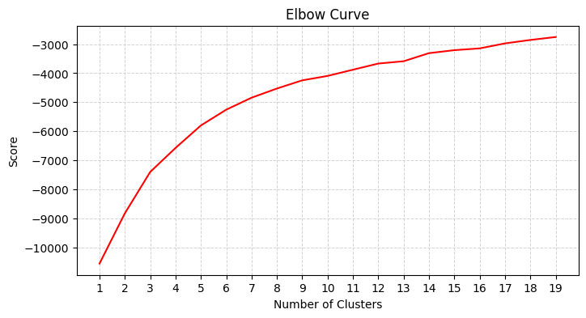

```python
# Definir un rango de posibles valores para el número de clusters a probar
Nc = range(1, 20)  # Evaluar desde 1 hasta 19 clusters

# Crear una lista de modelos KMeans para cada número de clusters en Nc
kmeans = [KMeans(n_clusters=i) for i in Nc]  # Inicializar el modelo KMeans para cada valor de Nc

# Calcular la puntuación (score) para cada modelo KMeans ajustado a los datos X
score = [kmeans[i].fit(X_scaled).score(X_scaled) for i in range(len(kmeans))]  # Ajustar y obtener la puntuación de cada modelo

# Configurar la figura para la visualización de la curva del codo
plt.figure(figsize=(8, 4))  # Establecer el tamaño de la figura para la gráfica

# Graficar el número de clusters versus la puntuación obtenida
plt.plot(Nc, score, color='red')  # Trazar la curva del codo con línea roja

# Añadir cuadrícula de fondo en color gris claro
plt.grid(color='lightgray', linestyle='--', linewidth=0.7)  # Establecer la cuadrícula con color y estilo

# Configurar el eje X para que muestre ticks de 3 en 3
plt.xticks(np.arange(1, 20, 1))  # Definir ticks en el eje X desde 1 hasta 19 en pasos de 3

# Etiquetas y título para el gráfico
plt.xlabel('Number of Clusters')  # Etiqueta del eje X que indica el número de clusters
plt.ylabel('Score')  # Etiqueta del eje Y que indica la puntuación del modelo
plt.title('Elbow Curve')  # Título de la gráfica que describe su contenido

plt.show()  # Mostrar la gráfica generada en pantalla
```

La curva presenta una transición gradual, lo que indica que el rendimiento del modelo no muestra cambios drásticos al aumentar el número de clusters. En este contexto, se sugiere que `3` es un valor óptimo para K, ya que proporciona un equilibrio entre la simplicidad del modelo y la capacidad de capturar la variabilidad de los datos.

```python
def kmeans_metrics(kmeans, cluster_labels, X_scaled):

    inercia = kmeans.inertia_
    print(f"Inercia: {inercia}")

    silhouette_avg = silhouette_score(X_scaled, cluster_labels)
    print(f"Índice de Silueta: {silhouette_avg}")

    calinski_harabasz = calinski_harabasz_score(X_scaled, cluster_labels)
    print(f"Coeficiente de Calinski-Harabasz: {calinski_harabasz}")

    davies_bouldin = davies_bouldin_score(X_scaled, cluster_labels)
    print(f"Índice de Davies-Bouldin: {davies_bouldin}")
```

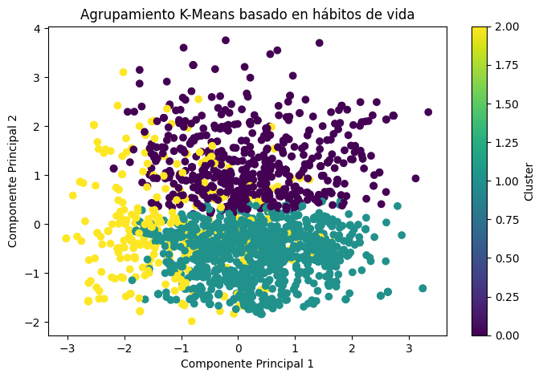

```
Inercia: 7414.753861183298
Índice de Silueta: 0.20483864580028713
Coeficiente de Calinski-Harabasz: 446.3829133479266
Índice de Davies-Bouldin: 1.7516157144173226
```

```python
# Definir el número de clústeres (en este caso, 3) para el algoritmo K-Means
k = 3 # Número de clústeres a generar

# Implementar K-Means para agrupamiento de datos
# Se utiliza el número de clústeres 'k' y se establece una semilla para asegurar la reproducibilidad
kmeans = KMeans(n_clusters=k, random_state=42)  # Inicializamos el modelo K-Means con 3 clústeres
labels_kmeans = kmeans.fit_predict(X_scaled)  # Ajustamos el modelo y predecimos las etiquetas de clústeres

# Añadir las etiquetas de clúster generadas al DataFrame original para identificar a qué clúster pertenece cada observación
df['Cluster'] = labels_kmeans  # Asignamos las etiquetas de los clústeres al DataFrame como una nueva columna

# Visualizar los clústeres utilizando los primeros dos componentes principales (PCA)
# Esto permite representar los datos en un plano 2D para observar cómo se distribuyen los clústeres
plt.figure(figsize=(8, 5))  # Establecemos el tamaño de la figura
plt.scatter(X_pca[:, 0], X_pca[:, 1], c=labels_kmeans, cmap='viridis', marker='o')  # Graficamos los puntos con colores según el clúster
plt.xlabel("Componente Principal 1")  # Etiqueta del eje X (primer componente principal)
plt.ylabel("Componente Principal 2")  # Etiqueta del eje Y (segundo componente principal)
plt.title("Agrupamiento K-Means basado en hábitos de vida")  # Título del gráfico
plt.colorbar(label='Cluster')  # Añadimos una barra de colores para indicar el clúster al que pertenece cada punto
plt.show()  # Mostramos el gráfico

kmeans_metrics(kmeans, labels_kmeans, X_scaled)
```

| Métrica | Valor | Comentarios |
| --- | --- | --- |
| **Inercia** | 7414.75 | Un valor relativamente alto, lo que sugiere que los puntos están más dispersos y alejados de sus centroides. Esto podría indicar una mala compactación de los clústeres. |
| **Índice de Silueta** | 0.2048 | El índice de silueta es bajo, lo que indica que los clústeres podrían estar solapados o no estar bien separados. Un valor cercano a 1 sería ideal para una buena separación. |
| **Coeficiente de Calinski-Harabasz** | 446.38 | Un valor moderado, lo que sugiere una dispersión razonable entre los clústeres. Aunque no es alto, muestra que hay algo de separación entre ellos. |
| **Índice de Davies-Bouldin** | 1.7516 | Un valor alto, lo que indica que los clústeres podrían tener una separación insuficiente. Idealmente, los valores más cercanos a 0 indican una mejor separación entre los clústeres. |

#### **⭕️ Contraste con la Variable Objetivo**

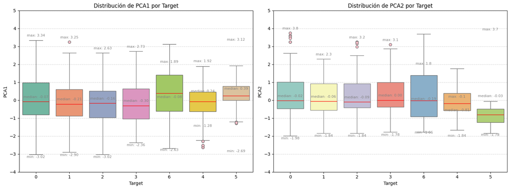

```python
def boxplot_kmeans(labels_kmeans, X_pca, y):
    results = pd.DataFrame({
        'K-Means': labels_kmeans
    })

    results['target'] = y
    results['PCA1'] = X_pca[:,0]
    results['PCA2'] = X_pca[:,1]

    # Calcular las medianas, mínimos y máximos de PCA1 y PCA2 por clase 'target'
    medianas_pca1 = results.groupby('target')['PCA1'].median()
    minimos_pca1 = results.groupby('target')['PCA1'].min()
    maximos_pca1 = results.groupby('target')['PCA1'].max()

    medianas_pca2 = results.groupby('target')['PCA2'].median()
    minimos_pca2 = results.groupby('target')['PCA2'].min()
    maximos_pca2 = results.groupby('target')['PCA2'].max()

    # Número de categorías en target
    num_categorias = results['target'].nunique()

    # Generar una paleta de colores automáticamente con el número de categorías
    colores_pca1 = sns.color_palette("Set2", num_categorias)
    colores_pca2 = sns.color_palette("Set3", num_categorias)

    # Crear figura
    plt.figure(figsize=(16, 6))

    # Primer gráfico de boxplot para PCA1
    plt.subplot(1, 2, 1)

    # Crear cada caja manualmente por categoría en PCA1
    for i, target in enumerate(results['target'].unique()):
        sns.boxplot(
            x=results[results['target'] == target]['target'],
            y=results[results['target'] == target]['PCA1'],
            color=colores_pca1[i],                    # Color específico para cada caja
            medianprops=dict(color='red'),            # Color de la mediana
            flierprops=dict(markerfacecolor='pink', marker='o')  # Color de puntos atípicos
        )

    # Añadir las medianas, mínimos y máximos de PCA1 en la gráfica
    for i, (median, minimo, maximo) in enumerate(zip(medianas_pca1, minimos_pca1, maximos_pca1)):
        plt.text(i, median + 0.2, f'median: {median:.2f}', ha='center', color='gray', fontsize=8)
        plt.text(i, minimo - 0.2, f'min: {minimo:.2f}', ha='center', color='gray', fontsize=8)
        plt.text(i, maximo + 0.2, f'max: {maximo:.2f}', ha='center', color='gray', fontsize=8)

    # Configuración del rango y ticks en el eje Y para PCA1
    plt.ylim(0, 5)
    plt.yticks(ticks=[-4, -3, -2, -1, 0, 1, 2, 3, 4, 5])

    plt.title('Distribución de PCA1 por Target')
    plt.xlabel('Target')
    plt.ylabel('PCA1')
    plt.grid(True, linestyle='--', color='lightgrey', axis='y')

    # Segundo gráfico de boxplot para PCA2
    plt.subplot(1, 2, 2)

    # Crear cada caja manualmente por categoría en PCA2
    for i, target in enumerate(results['target'].unique()):
        sns.boxplot(
            x=results[results['target'] == target]['target'],
            y=results[results['target'] == target]['PCA2'],
            color=colores_pca2[i],                    # Color específico para cada caja
            medianprops=dict(color='red'),            # Color de la mediana
            flierprops=dict(markerfacecolor='pink', marker='o')  # Color de puntos atípicos
        )

    # Añadir las medianas, mínimos y máximos de PCA2 en la gráfica
    for i, (median, minimo, maximo) in enumerate(zip(medianas_pca2, minimos_pca2, maximos_pca2)):
        plt.text(i, median + 0.2, f'median: {median:.2f}', ha='center', color='gray', fontsize=8)
        plt.text(i, minimo - 0.2, f'min: {minimo:.2f}', ha='center', color='gray', fontsize=8)
        plt.text(i, maximo + 0.2, f'max: {maximo:.1f}', ha='center', color='gray', fontsize=8)

    # Configuración del rango y ticks en el eje Y para PCA2
    plt.ylim(0, 5)
    plt.yticks(ticks=[-4, -3, -2, -1, 0, 1, 2, 3, 4, 5])

    plt.title('Distribución de PCA2 por Target')
    plt.xlabel('Target')
    plt.ylabel('PCA2')
    plt.grid(True, linestyle='--', color='lightgrey', axis='y')

    plt.tight_layout()
    plt.show()

boxplot_kmeans(labels_kmeans, X_pca, y)
```

#### **⭕️ Análisis de Grafico Distribución PCA1**

[output not shown]

- Los grupos de `Normal_Weight`, `Overweight_Level_II`, `Obesity_Type_I`, e `Insufficient_Weight` tienen distribuciones sin outliers, lo que sugiere que la mayoría de los valores de estos grupos están dentro de un rango similar.
- `` Overweight_Level_I``, Obesity_Type_II ``, y `Obesity_Type_III` tienen outliers, lo que sugiere que hay valores más dispersos que pueden indicar una mayor variabilidad en estos grupos.

#### **⭕️ Análisis de Grafico Distribución PCA2**

[output not shown]

- Los grupos de `Normal_Weight` y `Overweight_Level_II` tienen valores atípicos (outliers) en el límite superior, lo que sugiere que en esos grupos existen individuos con valores extremadamente altos en la componente PCA 2.
- `Obesity_Type_I` también muestra un outlier en PCA 2, pero los demás grupos, como `Insufficient_Weight`, `Obesity_Type_II`, y `Obesity_Type_III`, presentan distribuciones más homogéneas.

### **⚛️ Entrenamiento del Modelo Supervisado**

#### **⭕️ Selección del Modelo**

```python
# Convertir la variable objetivo (NObeyesdad) a valores numéricos si es necesario
# Usamos LabelEncoder para transformar las categorías a valores numéricos
label_encoder = LabelEncoder()
df['NObeyesdad_encoded'] = label_encoder.fit_transform(df['NObeyesdad'])

# Seleccionar las características (variables independientes) y la variable objetivo
X = df[['FCVC', 'NCP', 'CH2O', 'FAF', 'TUE', 'Cluster']]  # Características numéricas
y = df['NObeyesdad_encoded']  # Variable objetivo (Niveles de obesidad)

# Dividir los datos en conjunto de entrenamiento (80%) y prueba (20%)
X_train, X_test, y_train, y_test = train_test_split(X, y, test_size=0.2, random_state=42)

# Inicializar los modelos supervisados a evaluar
models = {
    'Random Forest': RandomForestClassifier(random_state=42),
    'Logistic Regression': LogisticRegression(max_iter=1000, random_state=42),
    'Support Vector Classifier (SVC)': SVC(random_state=42),
    'XGBoost': XGBClassifier(use_label_encoder=False, eval_metric='logloss', random_state=42)
}

# Entrenar y evaluar cada modelo
for model_name, model in models.items():
    print(f"\n*** Entrenando el modelo: {model_name} ***\n")

    # Ajustar el modelo con los datos de entrenamiento
    model.fit(X_train, y_train)

    # Realizar predicciones sobre el conjunto de prueba
    y_pred = model.predict(X_test)

    # Evaluar el modelo usando las métricas de rendimiento
    print(f"Reporte de clasificación para el modelo {model_name}:")
    print(classification_report(y_test, y_pred))

    # Calcular F1-Score y Recall
    f1 = f1_score(y_test, y_pred, average='weighted')  # F1-Score ponderado
    recall = recall_score(y_test, y_pred, average='weighted')  # Recall ponderado
    print(f"F1-Score ponderado para {model_name}: {f1:.4f}")
    print(f"Recall ponderado para {model_name}: {recall:.4f}")

    # Mostrar la matriz de confusión
    print(f"Matriz de confusión para el modelo {model_name}:")
    print(confusion_matrix(y_test, y_pred))
    print('---------------------------------------------------------------------------------------')
```

```
*** Entrenando el modelo: Random Forest ***

Reporte de clasificación para el modelo Random Forest:
              precision    recall  f1-score   support

           0       0.59      0.77      0.67        62
           1       0.52      0.29      0.37        56
           2       0.41      0.48      0.44        50
           3       0.59      0.50      0.54        78
           4       0.72      0.83      0.77        58
           5       0.98      1.00      0.99        63
           6       0.74      0.71      0.73        56

    accuracy                           0.66       423
   macro avg       0.65      0.65      0.64       423
weighted avg       0.65      0.66      0.65       423

F1-Score ponderado para Random Forest: 0.6477
Recall ponderado para Random Forest: 0.6572
Matriz de confusión para el modelo Random Forest:
[[48  1  6  3  0  0  4]
 [11 16 12  7  5  0  5]
 [ 6  3 24 12  3  0  2]
 [13  4 11 39 10  0  1]
 [ 3  1  1  3 48  0  2]
 [ 0  0  0  0  0 63  0]
 [ 1  6  5  2  1  1 40]]
---------------------------------------------------------------------------------------

*** Entrenando el modelo: Logistic Regression ***

Reporte de clasificación para el modelo Logistic Regression:
              precision    recall  f1-score   support

           0       0.24      0.19      0.22        62
           1       0.19      0.11      0.14        56
           2       0.13      0.06      0.08        50
           3       0.41      0.59      0.48        78
           4       0.18      0.17      0.17        58
           5       0.60      0.97      0.74        63
```

[output cut: 60 more lines]

```
    accuracy                           0.62       423
   macro avg       0.60      0.61      0.60       423
weighted avg       0.61      0.62      0.61       423

F1-Score ponderado para XGBoost: 0.6077
Recall ponderado para XGBoost: 0.6170
Matriz de confusión para el modelo XGBoost:
[[45  2  7  3  0  0  5]
 [11 17  9  5  7  0  7]
 [ 5  7 15 14  3  1  5]
 [13  3 13 39  8  0  2]
 [ 2  1  3  6 44  0  2]
 [ 0  0  0  0  0 63  0]
 [ 2  6  3  3  2  2 38]]
---------------------------------------------------------------------------------------
```

#### ⭕️ **Análisis de Mejor Desempeño Basado en Métricas de Evaluación**

El análisis de desempeño basado en métricas cuantitativas permite identificar el rendimiento de distintos modelos y seleccionar el más adecuado según su precisión y consistencia. Evaluando el desempeño de cada modelo a través de métricas clave como precisión, recall y f1-score, se pueden optimizar las decisiones para mejorar la eficiencia de clasificación.

- **Precisión**: Proporción de predicciones correctas en las clases positivas predichas.
- **Recall**: Proporción de verdaderos positivos entre todos los positivos reales.
- **F1-Score**: Media armónica entre precisión y recall, útil para evaluar el equilibrio de ambos aspectos.. |

[output not shown]

#### ⭕️ **Análisis de Mejor Desempeño Basado en Matriz de Confusión**

El análisis de matrices de confusión permite evaluar el desempeño de los modelos de clasificación al visualizar las predicciones correctas y los errores cometidos en cada clase. A través de esta matriz, se puede identificar la precisión y los puntos débiles de cada modelo.

[output not shown]

### **🧩 Ajuste de Hiperparámetros con Grid Search**

#### **☑️ Definición de rangos de hiperparámetros para RandomForest**

```python
# Parámetros para RandomForestClassifier
rf_param_grid = {
    'n_estimators': [100, 200, 300],           # Número de árboles en el bosque (mayor número puede mejorar la precisión pero aumenta el tiempo de cómputo)
    'max_depth': [None, 10, 20],               # Profundidad máxima de cada árbol (None significa que los nodos se expanden hasta ser puros)
    'min_samples_split': [2, 5, 10],           # Número mínimo de muestras necesarias para dividir un nodo interno (valor más alto puede reducir el sobreajuste)
    'min_samples_leaf': [1, 2, 4],             # Número mínimo de muestras necesarias en una hoja (puede ayudar a reducir el sobreajuste si aumenta)
    'bootstrap': [True, False]                 # Si es True, las muestras son tomadas con reemplazo; si es False, sin reemplazo
}

#Eliminación de la variable Cluster para que despues de optimizado y guardado el modelo no se deba soliciar como input.
_X_train = X_train.drop(columns=['Cluster'], errors='ignore')
_X_test = X_test.drop(columns=['Cluster'], errors='ignore')

# Creación del modelo RandomForest
rf_model_grid = RandomForestClassifier(random_state=42)

# Configuración de GridSearch para RandomForest
grid_search_rf = GridSearchCV(estimator=rf_model_grid, param_grid=rf_param_grid, cv=5, n_jobs=-1, verbose=2)
grid_search_rf.fit(_X_train, y_train)  # Entrenar el modelo con el conjunto de entrenamiento

# Mejor combinación de parámetros encontrada para RandomForest
best_rf_model_grid = grid_search_rf.best_estimator_
print(f'Mejores parámetros para RandomForest: {grid_search_rf.best_params_}')
```

```
Fitting 5 folds for each of 162 candidates, totalling 810 fits
Mejores parámetros para RandomForest: {'bootstrap': False, 'max_depth': None, 'min_samples_leaf': 1, 'min_samples_split': 2, 'n_estimators': 200}
```

#### **☑️ Detalles de la salida**

#### Proceso de validación cruzada (cross-validation) en el que se entrenan múltiples modelos con diferentes combinaciones de hiperparámetros para evaluar su rendimiento. En este caso:

- `5 folds`: Significa que el conjunto de datos se divide en 5 partes, y cada parte se usa una vez como conjunto de prueba.
- `162 candidates`: Hay 162 combinaciones diferentes de hiperparámetros que se están evaluando.
- `810 fits`: El número total de veces que el modelo se ajusta a los datos es 810, ya que 5 (folds) por 162 (candidatos) da 810.

| Parámetro | Explicación | Interpretación del Valor |
| --- | --- | --- |
| **`bootstrap`** | Indica si se realiza el muestreo con reemplazo en la construcción de árboles. | **`False`** significa que no se usa muestreo con reemplazo, es decir, se utiliza el conjunto completo de datos para cada árbol. Esto puede llevar a un mayor ajuste del modelo a los datos. |
| **`max_depth`** | Controla la profundidad máxima de cada árbol. | **`None`** indica que no se limita la profundidad de los árboles. Esto puede llevar a árboles más complejos, lo que podría aumentar el riesgo de sobreajuste (overfitting). |
| **`min_samples_leaf`** | Número mínimo de muestras necesarias para ser una hoja del árbol. | **`1`** significa que cualquier cantidad de muestras puede ser una hoja, lo que permite una mayor flexibilidad en la partición de los datos y podría generar árboles muy detallados. |
| **`min_samples_split`** | Número mínimo de muestras necesarias para dividir un nodo interno. | **`2`** significa que cualquier nodo con al menos 2 muestras puede ser dividido, lo que permite una mayor capacidad de división y una mayor complejidad en los árboles. |
| **`n_estimators`** | Número de árboles en el bosque. | **`200`** indica que se utilizarán 200 árboles. Esto puede mejorar la estabilidad y precisión del modelo, pero también aumenta el tiempo de computación. |

```python
# Creación del modelo RandomForestClassifier con parámetros optimizados
rf_model_optimo = RandomForestClassifier(
    bootstrap=False,  # Indica que no se realiza el muestreo con reemplazo (sin bootstrap)
    max_depth=None,   # No se limita la profundidad de los árboles, lo que permite que crezcan hasta que todos los nodos sean puros
    min_samples_leaf=1,  # Cada hoja puede tener solo una muestra, lo que permite mayor flexibilidad y un ajuste detallado de los datos
    min_samples_split=2,  # Cualquier nodo con al menos 2 muestras puede dividirse, lo que aumenta la capacidad de división del árbol
    n_estimators=200,  # Se utilizarán 200 árboles en el bosque, lo que mejora la estabilidad y precisión del modelo, pero aumenta el tiempo de computación
    random_state=42  # Fijar la semilla aleatoria para garantizar la reproducibilidad de los resultados
)

# Entrenar el modelo en el conjunto de entrenamiento
best_rf_model_grid.fit(_X_train, y_train)

# Hacer predicciones en el conjunto de prueba
y_pred_optimo1 = best_rf_model_grid.predict(_X_test)

# Obtener las probabilidades de predicción en el conjunto de prueba (si es necesario)
y_probs_optimo1 = best_rf_model_grid.predict_proba(_X_test)
```

```python
f1 = f1_score(y_test, y_pred_optimo1, average='weighted')  # F1-Score ponderado
recall = recall_score(y_test, y_pred_optimo1, average='weighted')  # Recall ponderado

# Imprimir el reporte de clasificación
print("Reporte de clasificación:")
print(classification_report(y_test, y_pred_optimo1))

# Imprimir F1-Score y Recall
print(f"F1-Score ponderado: {f1:.4f}")
print(f"Recall ponderado: {recall:.4f}")

# Imprimir matriz de confusión
print("Matriz de confusión:")
print(confusion_matrix(y_test, y_pred_optimo1))
```

```
Reporte de clasificación:
              precision    recall  f1-score   support

           0       0.59      0.81      0.68        62
           1       0.57      0.38      0.45        56
           2       0.44      0.48      0.46        50
           3       0.65      0.54      0.59        78
           4       0.80      0.83      0.81        58
           5       0.98      1.00      0.99        63
           6       0.70      0.71      0.71        56

    accuracy                           0.68       423
   macro avg       0.67      0.68      0.67       423
weighted avg       0.68      0.68      0.67       423

F1-Score ponderado: 0.6749
Recall ponderado: 0.6809
Matriz de confusión:
[[50  3  5  0  0  0  4]
 [12 21  8  7  2  0  6]
 [ 6  3 24 11  2  0  4]
 [12  5 11 42  7  0  1]
 [ 3  0  2  3 48  0  2]
 [ 0  0  0  0  0 63  0]
 [ 2  5  5  2  1  1 40]]
```

#### **💥 Definición de rangos de hiperparámetros para Kmeans**

```python
# Definición de la grilla de parámetros para la optimización de KMeans
kmeans_param_grid = {
    'n_clusters': [2, 3, 4, 5, 6],  # Número de clústeres a crear, variando entre 2 y 6 para evaluar el mejor valor
    'init': ['k-means++', 'random'],  # Método para inicializar los centros de los clústeres: 'k-means++' busca una inicialización más eficiente, mientras que 'random' es una inicialización aleatoria
    'max_iter': [300, 500],  # Número máximo de iteraciones para la convergencia del algoritmo
    'n_init': [10, 20]  # Número de veces que el algoritmo se ejecutará con diferentes inicializaciones para encontrar el mejor resultado
}

# Creación del modelo KMeans
kmeans_grid = KMeans(random_state=42)

# Configuración de GridSearch para KMeans
grid_search_kmeans_grid = GridSearchCV(estimator=kmeans_grid, param_grid=kmeans_param_grid, cv=5, n_jobs=-1, verbose=2)
grid_search_kmeans_grid.fit(_X_train)  # Entrenar el modelo con las características agrupadas

# Mejor combinación de parámetros encontrada para KMeans
best_kmeans_model_grid = grid_search_kmeans_grid.best_estimator_
print(f'Mejores parámetros para KMeans: {grid_search_kmeans_grid.best_params_}')
```

```
Fitting 5 folds for each of 40 candidates, totalling 200 fits
Mejores parámetros para KMeans: {'init': 'k-means++', 'max_iter': 300, 'n_clusters': 6, 'n_init': 20}
```

#### **✳️ Predicción de Clusters**

```python
# Crear el modelo KMeans con los parámetros especificados
kmeans1 = KMeans(
    init='k-means++',  # Inicialización de los centroides de manera inteligente
    max_iter=300,      # Número máximo de iteraciones para optimizar los centroides
    n_clusters=6,      # Número de clústeres que deseas identificar
    n_init=20,         # Número de inicializaciones diferentes para elegir la mejor
    random_state=42    # Para asegurar la reproducibilidad de los resultados
)

# Ajustar el modelo KMeans a las probabilidades de las clases (y_probs)
cluster_labels1 = kmeans1.fit_predict(X_scaled)  # Predicción de clústeres
print(cluster_labels1)
kmeans_metrics(kmeans1, cluster_labels1, X_scaled)
```

```
[2 5 5 ... 1 0 0]
Inercia: 5222.163239456246
Índice de Silueta: 0.20545825041732615
Coeficiente de Calinski-Harabasz: 429.926359289788
Índice de Davies-Bouldin: 1.3238854092269057
```